# The relationship between getting pregnant, getting STDs and getting AIDs.

Spring 2015

## Variables:

Three categorical variables relevant to *teen pregnancy* are `H1RP1-H1RP6` from the `AddHealth` data set. The `AddHealth` data set is loaded from the `PDS` package. Using the `dplyr` package, a new data frame `NDF` containing only three variables after renaming `H1RP1-H1RP6` to `GettingPregnant`, `SexuallyTransmittedDiseases`, and `AIDs` is created.

```r
library(PDS)
library(dplyr)
NDF <- AddHealth %>%
  rename(GettingPregnant= H1RP1, SexuallyTransmittedDiseases = H1RP4, AIDs = H1RP3) %>%
  select(GettingPregnant, SexuallyTransmittedDiseases, AIDs)
head(NDF)
```

```
  GettingPregnant SexuallyTransmittedDiseases AIDs
1               5                           4    1
2               5                           4    2
3               3                           5    2
4               5                           1    1
5               2                           2    2
6               7                           7    7
```

Responses of `9` for question `GettingPregnant` are recoded to `NA`.

```r
xtabs(~GettingPregnant, data = NDF)
```

```
GettingPregnant
   1    2    3    4    5    6    7    8    9
2615 1112  356  253   91    8 2039   29    1
```

```r
NDF$GettingPregnant[NDF$GettingPregnant == 9] <- NA
xtabs(~GettingPregnant, data = NDF)
```

```
GettingPregnant
   1    2    3    4    5    6    7    8    9
2615 1112  356  253   91    8 2039   29    0
```

```r
NDF$GettingPregnant <- factor(NDF$GettingPregnant, labels = c("Strongly Agree", "Agree", "Neither agree nor disagree", "Disagree","Strongly Disagreed","Refused", "Legitimate Skip" ,"Don't know"))[, drop = TRUE]
xtabs(~GettingPregnant, data = NDF)
```

```
GettingPregnant
            Strongly Agree                      Agree
                      2615                       1112
Neither agree nor disagree                   Disagree
                       356                        253
        Strongly Disagreed                    Refused
                        91                          8
           Legitimate Skip                 Don't know
                      2039                         29
```

```r
summary(NDF$GettingPregnant)
```

```
            Strongly Agree                      Agree
                      2615                       1112
Neither agree nor disagree                   Disagree
                       356                        253
        Strongly Disagreed                    Refused
                        91                          8
           Legitimate Skip                 Don't know
                      2039                         29
                      NA's
                         1
```

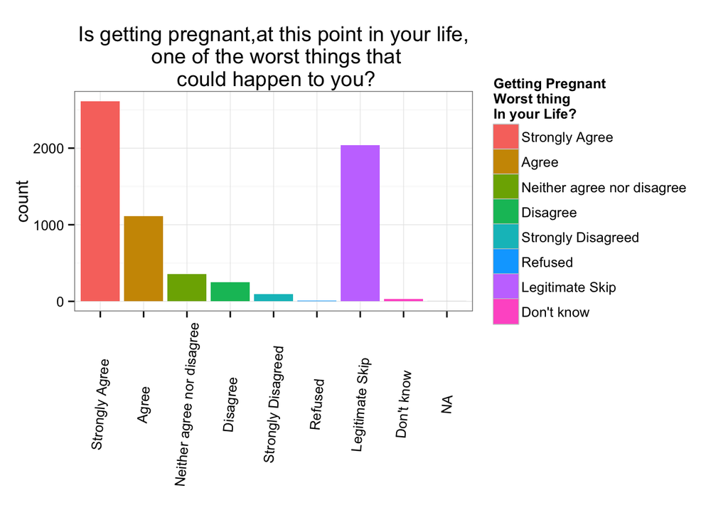

```r
ggplot(data = NDF, aes(x = GettingPregnant, fill = GettingPregnant)) +
  geom_bar() +
  labs(title ="Is getting pregnant,at this point in your life,\n one of the worst things that\n could happen to you?", x = "") +
  theme_bw() +  theme(axis.text.x  = element_text(angle = 85, vjust = 0.5)) +
  guides(fill = guide_legend(title = "Getting Pregnant\nWorst thing\nIn your Life?"))
```

This graph shows the survey of those who agree versus disagree that getting pregnant can be one of the worst things that happen to them.

Question `SexuallyTransmittedDiseases` asks therespondents “Would it be a big hassle to protect yourself from STDs?” Responses of 9 are recoded to `NA`.

```r
xtabs(~SexuallyTransmittedDiseases, data = NDF)
```

```
SexuallyTransmittedDiseases
   1    2    3    4    5    6    7    8    9
 346  464  321 1392 1882    5 2039   54    1
```

```r
NDF$SexuallyTransmittedDiseases[NDF$SexuallyTransmittedDiseases==9] <- NA
xtabs(~SexuallyTransmittedDiseases, data = NDF)
```

```
SexuallyTransmittedDiseases
   1    2    3    4    5    6    7    8    9
 346  464  321 1392 1882    5 2039   54    0
```

```r
NDF$SexuallyTransmittedDiseases <- factor(NDF$SexuallyTransmittedDiseases)[, drop = TRUE]
xtabs(~SexuallyTransmittedDiseases, data = NDF)
```

```
SexuallyTransmittedDiseases
   1    2    3    4    5    6    7    8
 346  464  321 1392 1882    5 2039   54
```

```r
NDF$SexuallyTransmittedDiseases <- factor(NDF$SexuallyTransmittedDiseases, labels = c("Strongly Agree", "Agree", "Neither Agree nor Disagree", "Disagree", "Strongly Disagree", "refused","Legitimate skip", "don't know"))
```

```r
summary(NDF$SexuallyTransmittedDiseases)
```

```
            Strongly Agree                      Agree
                       346                        464
Neither Agree nor Disagree                   Disagree
                       321                       1392
         Strongly Disagree                    refused
                      1882                          5
           Legitimate skip                 don't know
                      2039                         54
                      NA's
                         1
```

```r
xtabs(~SexuallyTransmittedDiseases, data = NDF)
```

```
SexuallyTransmittedDiseases
            Strongly Agree                      Agree
                       346                        464
Neither Agree nor Disagree                   Disagree
                       321                       1392
         Strongly Disagree                    refused
                      1882                          5
           Legitimate skip                 don't know
                      2039                         54
```

```r
NAS <- sum(xtabs(~SexuallyTransmittedDiseases, data = NDF)[2:5])
NAS
```

```
[1] 4059
```

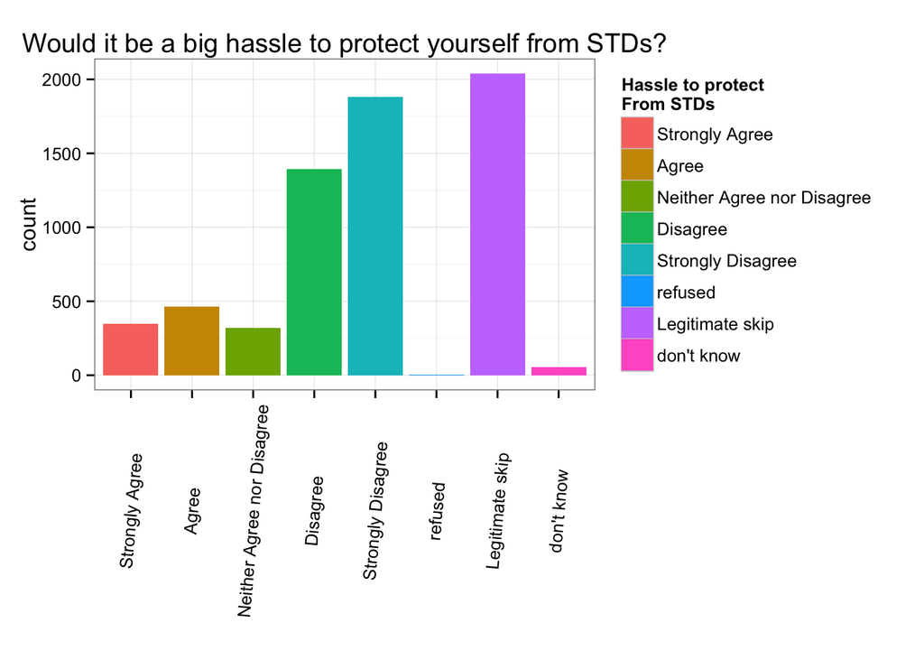

```r
ggplot(data = na.omit(NDF[ , "SexuallyTransmittedDiseases", drop = FALSE]),
       aes(x = SexuallyTransmittedDiseases, fill = SexuallyTransmittedDiseases)) +
  geom_bar() +
  labs(title = "Would it be a big hassle to protect yourself from STDs?", x = "") +
  theme_bw() + theme(axis.text.x  = element_text(angle = 85, vjust = 0.5))+
  guides(fill = guide_legend(title = "Hassle to protect\nFrom STDs"))
```

This survey displays whether the participants agree or disagree that it would be hard to protect themselves against STDs.

Question `AIDs` asks “What is the chance that you would get the AIDs virus?” A response of 9 should be recoded to `NA`.

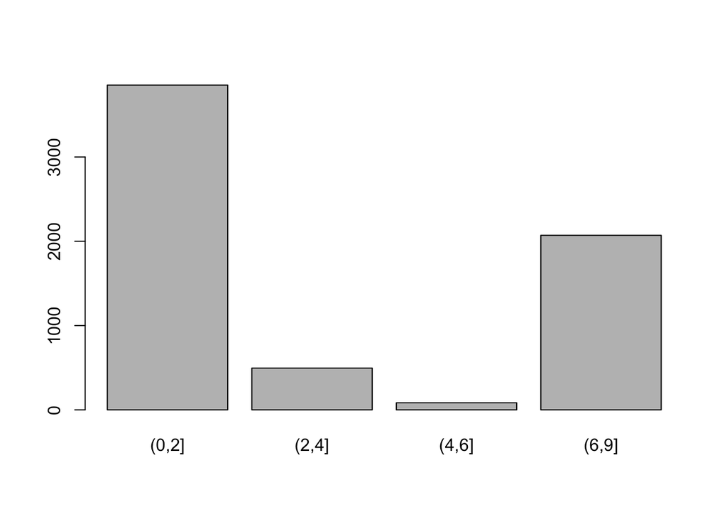

```r
NDF$AIDs[NDF$AIDs == 9] <- NA
New <-table(cut(as.numeric(NDF$AIDs),breaks=c(0,2,4,6,9)))
barplot(New)
```

```r
New1<-as.factor(New)



NDF$AIDs <- factor(NDF$AIDs, labels = c("Almost no", "Some", "Half & half ","good", "Almost certain", "Refused", "Legitimate Skip","Don't Know"))[, drop = TRUE]
xtabs(~AIDs, data = NDF)
```

```
AIDs
      Almost no            Some    Half & half             good
           2788            1065             339             157
 Almost certain         Refused Legitimate Skip      Don't Know
             78               6            2039              32
```

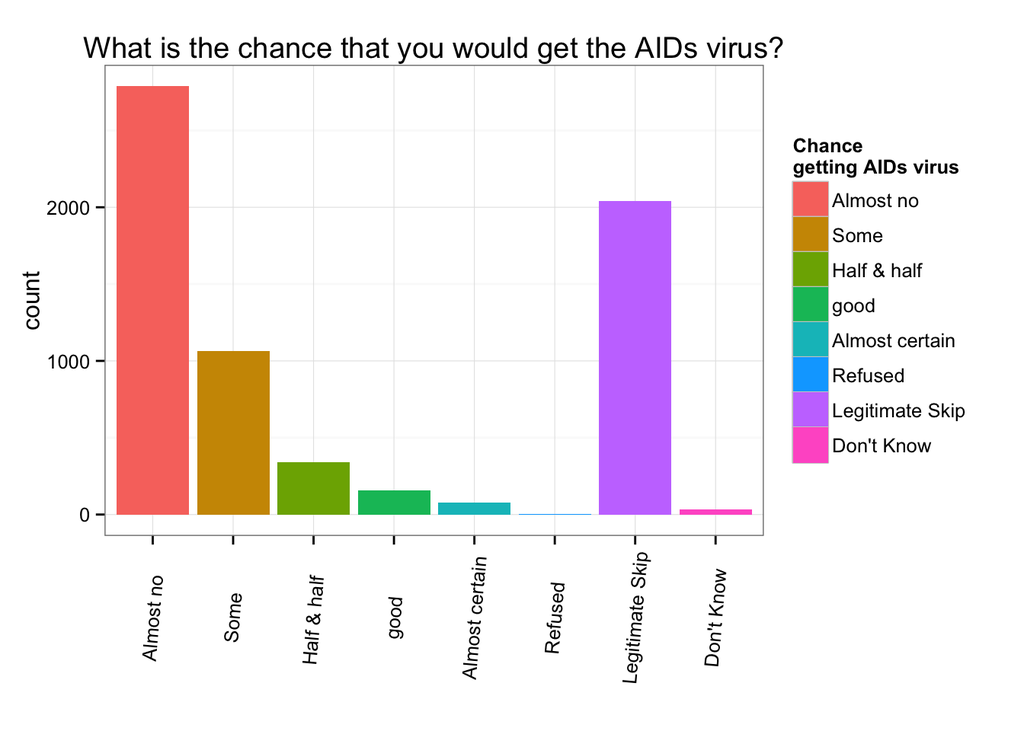

```r
ggplot(data = na.omit(NDF[ , "AIDs", drop = FALSE]), aes(x = AIDs, fill =AIDs)) +
  geom_bar()  +
  labs(title = "What is the chance that you would get the AIDs virus?", x = "") +
  theme_bw() +   theme(axis.text.x  = element_text(angle = 85, vjust = 0.5)) +
  guides(fill = guide_legend(title = "Chance\ngetting AIDs virus"))
```

This graph displays the chances of the participants getting the AIDs virus.

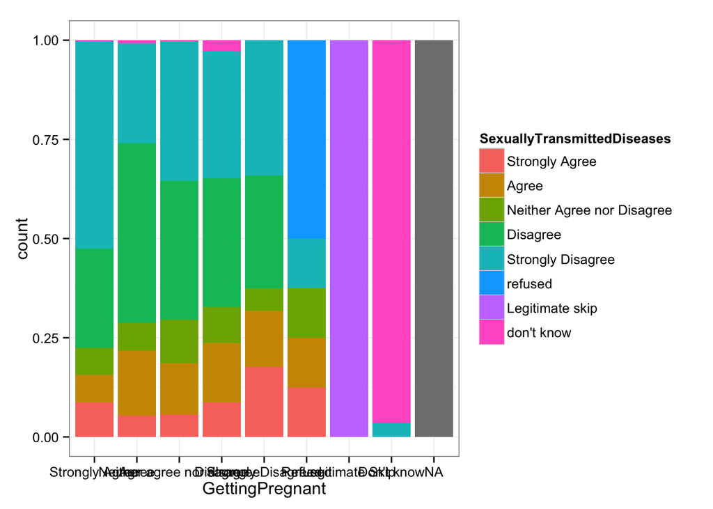

```r
g1 <- ggplot(data = NDF, aes(x = GettingPregnant, fill = SexuallyTransmittedDiseases)) +
  geom_bar(position = "fill") +
  theme_bw()
g1
```

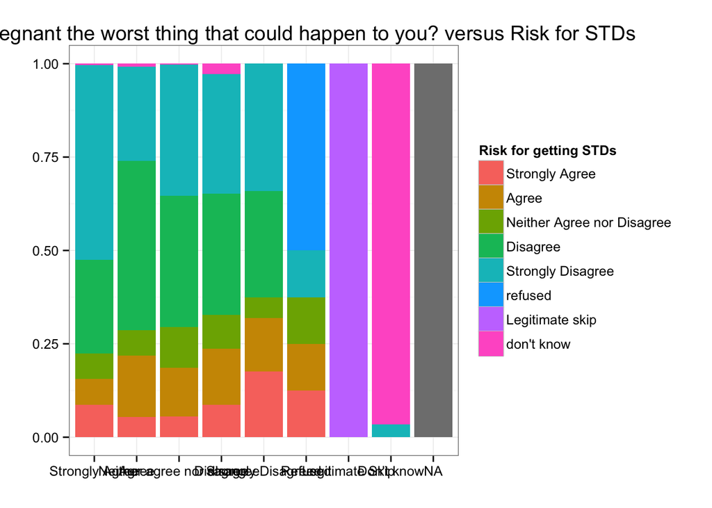

```r
g1 +
  labs(x = "", y = "", title = "Is Getting Pregnant the worst thing that could happen to you? versus Risk for STDs ") +
  scale_fill_discrete(name="Risk for getting STDs")
```

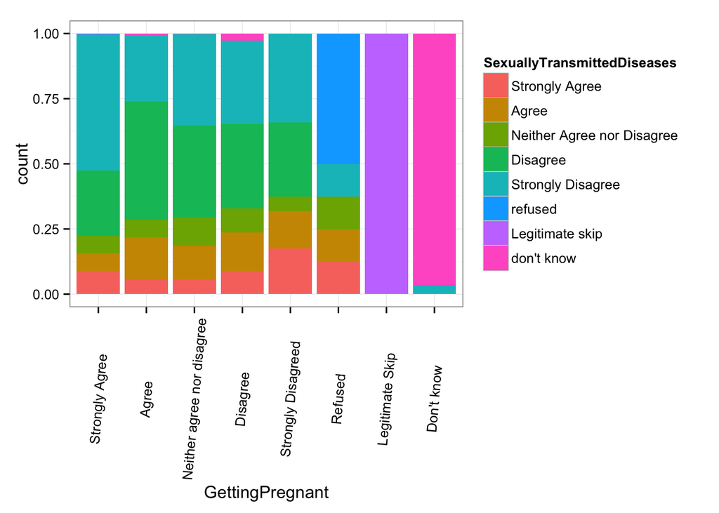

```r
g2 <- ggplot(data = na.omit(NDF), aes(x = GettingPregnant, fill = SexuallyTransmittedDiseases)) +
  geom_bar(position = "fill") +
  theme_bw() + theme(axis.text.x  = element_text(angle = 85, vjust = 0.5))
g2
```

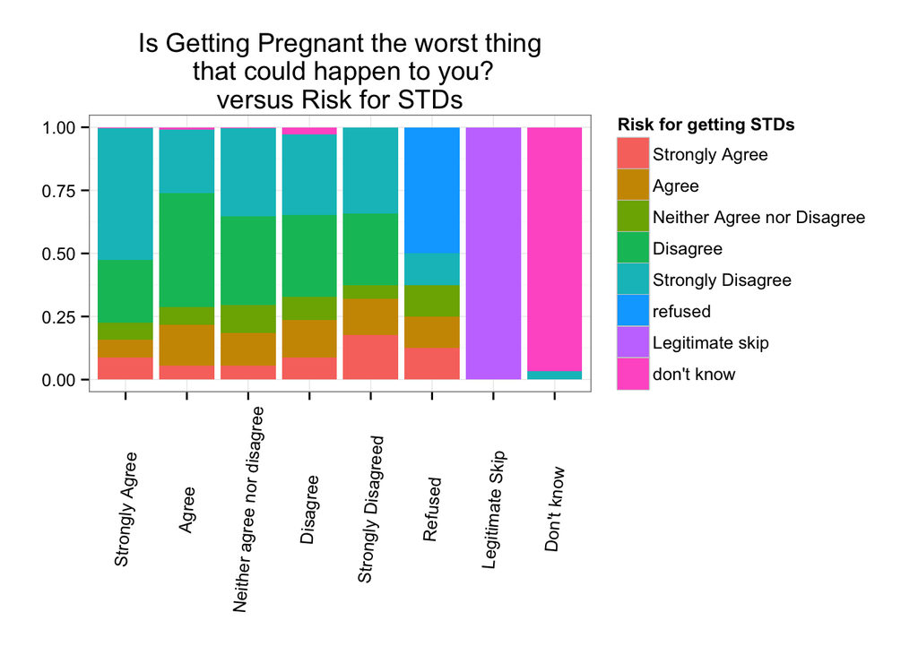

```r
g2 + labs(x = "", y = "", title = "Is Getting Pregnant the worst thing\n that could happen to you?\n versus Risk for STDs ") +
  scale_fill_discrete(name="Risk for getting STDs")
```

This graph shows two variables and compares getting pregnant being the worst thing versus the risk of STDs.

```r
g3 <- g2 + facet_grid(AIDs~ .) +
  theme(axis.text.x  = element_text(angle = 85, vjust = 0.5)) +
  labs(x = "", y = "", title = "Is Getting Pregnant the worst thing \n that could happen to you? \n versus Risk for STDs \n versus Risk for getting AIDs") +
  scale_fill_discrete(name="Risk for getting STDs")
 g3
```

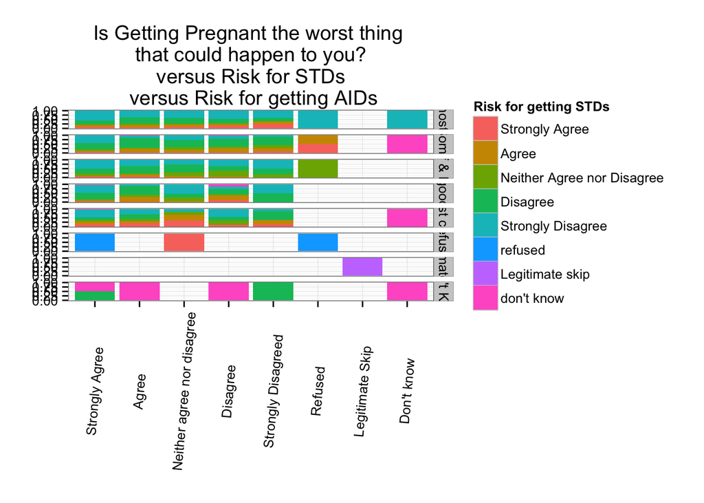